# Prinsimp

Principal Components Analysis (PCA) is a common way to study the sources of variation in a high-dimensional data set. Typically, the leading principal components are used to understand the variation in the data or to reduce the dimension of the data for subsequent analysis. The remaining principal components are ignored since they explain little of the variation in the data. However, the space spanned by the low variation principal components may contain interesting structure, structure that PCA cannot find. *Prinsimp* is an R package that looks for interesting structure of low variability. “Interesting” is defined in terms of a simplicity measure. Looking for interpretable structure in a low variability space has particular importance in evolutionary biology, where such structure can signify the existence of a genetic constraint.

Jonathan Zhang (Statistics Department, University of British Columbia) , Nancy Heckman (Statistics Department, University of British Columbia) , Davor Cubranic (Statistics Department, University of British Columbia) , Joel G. Kingsolver (Department of Biology, University of North Carolina) , J.S. Marron (Statistics Department, University of North Carolina) , Travis L. Gaydos (The MITRE Corporation)  
2014-09-28

## 1 Principal component analysis

Principal Components Analysis is simply an eigenanalysis of a covariance or correlation matrix. To learn more about PCA, see any standard multivariate analysis text, such as (Johnson and Wichern 2007). Through an eigenanalysis, a $d \times d$ covariance matrix $G$ can be decomposed in terms of its eigenvectors, ${{v}}_1,\ldots, {{v}}_d$, and the corresponding eigenvalues, $\lambda_1,\ldots, \lambda_d$: $G = \sum_1^d \lambda_j {{v}}_j {{v}}_j^T$. The eigenvalue, $\lambda_j$, can be interpreted as the variance in $G$ in the direction of ${{v}}_j$ and $\lambda_j/\sum_{k=1}^d \lambda_k$ as the proportion of variance explained by ${{v}}_j$. Often, $G$ is well-approximated using the first $J$ eigenvectors and eigenvalues. Typically, data analysts only consider these $J$ eigenvectors, and for that reason, we call the space that these eigenvectors span the *model space*. We call the orthogonal complement of the model space (which is simply the space spanned by the last $d-J$ eigenvectors) the *nearly null space*.

Researchers can use existing R functions `princomp` and `prcomp` to calculate the eigenvectors, eigenvalues and proportion of variance explained. Likewise, our library [*prinsimp*](https://CRAN.R-project.org/package=prinsimp) (Cubranic et al. 2013) can be used to study eigenvectors and their properties. In addition, *prinsimp* allows researchers to more carefully study the nearly null space, by calculating simple and easily interpretable basis vectors.

We focus on analysis of covariance matrices, although the user can input a correlation matrix for analysis. As in usual PCA, the choice between using a correlation matrix and a covariance matrix depends upon the types of responses and the question of interest. A correlation matrix should be used when the responses under consideration have non-comparable units of measurement, such as meters for measuring the response, height, and kilograms for measuring the response, weight. In all of our applications, the responses are directly comparable: they are from the same variable measured under different conditions (e.g., the variable weight measured at different ages). To study structure in such data, analysis of the covariance matrix is most useful. In addition, such data usually have natural simplicity measures, whereas non-comparable data do not.

Details of the methodology that *prinsimp* implements appear in Gaydos et al. (2013), a paper which also discusses the importance of studying genetic constraints.

## 2 Simplicity and the simplicity basis

The simplicity of a vector ${{v}}\in \Re^d$ is defined in terms of a non-negative definite symmetric $d \times d$ matrix $\Lambda$: the simplicity of ${{v}}$ is equal to ${{v}}^T \Lambda {{v}}$, with large values meaning ${{v}}$ is simple. This simplicity measure allows us to construct the *simplicity basis* of the $L=d-J$ dimensional nearly null space.

A simplicity basis for an $L$-dimensional linear subspace ${\cal{V}}$ of $\Re^d$ is an orthonormal basis $\{{{w}}_1, \dots , {{w}}_L\}$ where the ${{w}}_k$’s are in decreasing order of simplicity, as defined by $\Lambda$. To calculate a simplicity basis, first let ${{u}}_1, \dots , u_L$ be an orthonormal basis of ${\cal{V}}$ and let $P$ be the $d \times L$ matrix with $k$th column equal to ${{u}}_k$. So $P$ is a projection matrix onto ${\cal{V}}$. Let ${{a}}_1, \dots , {{a}}_L$ be the eigenvectors of $P^T \Lambda P$ with corresponding eigenvalues $\gamma_1 \geq \gamma_2 \geq \dots \geq \gamma_L$. Then it is straightforward to show that $\{P {{a}}_1 , \dots , P {{a}}_L\}$ is a simplicity basis of ${\cal{V}}$. If the eigenvalues of $\Lambda$ are distinct, then any orthonormal basis $\{{{u}}_1,\ldots, {{u}}_L\}$ will lead to the same set of $\{{{w}}_1,\ldots, {{w}}_L\}$. For our purposes, we set $\{{{u}}_1,\ldots, {{u}}_L\}$ equal to the last $L$ eigenvectors of $G$.

Note that we require that simple $v$’s have large values of ${{v}}^T\Lambda {{v}}$. However, in some cases, the simplicity measure is most easily defined in terms of a non-negative definite matrix $\Lambda^*$ with simple ${{v}}$’s having *small* values of ${{v}}^{T} \Lambda^* v$. In such a case, we simply set $\Lambda = \lambda^* {\rm{I}} - \Lambda^*$ where $\lambda^*$ is the largest eigenvalue of $\Lambda^*$. Then $\Lambda$ is non-negative definite and simple $v$’s will have large values of ${{v}}^T \Lambda {{v}}$, as desired.

Examples of quadratic simplicity measures can be found in smoothing and penalized regression. See Eilers and Marx (1996) and Green and Silverman (1994). Different examples of simplicity measures are discussed in the next section, in particular the built-in measures of the `simpart` function.

## 3 Examples of simplicity measures

The function `simpart` has three built-in simplicity measures of vectors in $\Re^d$: the default measure based on first divided differences as defined in Gaydos et al. (2013), another measure based on second divided differences and a third based on periodicity. These three measures are defined in terms of a vector ${{x}}\in \Re^d$ containing values of an explanatory variable. The periodicity simplicity measure is most natural when ${{x}}$ contains times and the researcher believes that responses are periodic or approximately periodic with known period.

### 3.1 Simplicity measure of a vector $v$ using divided differences based on ${{x}}$

Divided differences are often used to approximate derivatives of a function. For instance, the first divided difference of the differentiable function $f$ using $x_1$ and $x_2$ is $[f(x_2)-f(x_1)]/[x_2-x_1]$, which serves as an approximation of $f'(x_1)$. Our divided difference simplicity measures are appropriate when the observed data can be considered as arising from function evaluations.

To define a divided difference simplicity measure of a vector based on the vector of explanatory variables, ${{x}}=(x[1],\ldots, x[d])^T$, let the $(d-1) \times d$ difference matrix $D_d$ be
$$\begin{aligned}
D_d= \begin{pmatrix}
-1 & 1 & 0 & \cdots & 0\\
0 & -1 & 1 & \cdots & \vdots\\
\vdots&&\ddots&\ddots&0\\
0&\cdots&0&-1&1
\end{pmatrix}
\nonumber
\end{aligned}$$
and let $W$ be the $(d-1) \times (d-1)$ diagonal matrix with $W[j,j] = x[j+1]-x[j]$, that is, with the diagonal of $W$ equal to $D_d {{x}}$.

#### First divided difference simplicity measure of ${{v}}$ based on ${{x}}$

The first divided difference simplicity measure of the vector ${{v}}=(v[1],\ldots, v[d])^T$ is the default measure in `simpart`. To define it, write
$$\begin{aligned}
\displaystyle\sum\limits_{j=1}^{d-1} \frac {\left(v[{j+1}] - v[{j}]\right)^2}{x[j+1]-x[j] } = || W^{-1/2} D_d {{v}}||^2 = {{v}}^T D_d^T W^{-1} D_d {{v}}.
\nonumber
\end{aligned}$$
This expression is a *complexity measure*, with large values indicating that $v$ is complex. However, we will define a *simplicity measure*, with large values indicating that $v$ is simple. In addition, we will scale our measure using a result of (Schatzman 2002), that the eigenvalues of $D_d^T W^{-1} D_d$ are always between $0$ and $4/\underline{\Delta}_x$, where $\underline{\Delta}_x \equiv \min_j{x[j+1]-x[j]}$. We define the simplicity of $v$ as $v'\Lambda_1 v$ where $\Lambda_1 = 4 I -\underline{\Delta}_x D_d^T W^{-1} D_d$. Then the value of this simplicity measure is always between 0 and 4 and the simplest vector $v$ satisfies $\sum_{j=1}^{d-1} \big(v[{j+1}] - v[{j}]\big)^2/(x[j+1]-x[j] ) = 0$, that is, the components of ${{v}}$ are equal.

#### Second divided difference simplicity measure of ${{v}}$ based on ${{x}}$

To define the simplicity measure based on second divided differences, let
$$\delta_{j} = \frac{v[{j+2}] - v[{j+1}]}{x[j+2]-x[j+1]} - \frac{v[{j+1}] - v[{j}]}{x[j+1]-x[j] }
, ~~ j= 1 , \ldots, d-2.
\nonumber$$
Our simplicity measure of the vector $v$ is defined in terms of

$$\begin{aligned}
\displaystyle\sum\limits_{j=1}^{d-2} \frac{\delta_{j} ^2}{x[{j+2}]-x[j]}.
\label{eq:second.complexity}
\end{aligned} \tag{1}$$

We consider ${{v}}$ *simple* if this expression is small. One can easily show that this sum of squares is equal to $0$ if and only if $v[j] = \alpha + \beta x[j]$ for some $\alpha$ and $\beta$.

To write ((1)) in matrix form, write
$$\begin{pmatrix}
\delta_{1}
\\
\vdots
\\
\delta_{d-2}
\end{pmatrix}
= D_{d-1} W^{-1} D_d {{v}}$$
and let $W_2$ be the $(d-2) \times (d-2)$ diagonal matrix with $W_2[j,j] = x[{j+2}]-x[j]$. Thus ((1)) is equal to ${{v}}^T D_d^T W^{-1} D_{d-1}^T W_2^{-1} D_{d-1} W^{-1} D_d {{v}}$ $\equiv {{v}}^T \Lambda_2^* {{v}}$. To make this a simplicity measure, we set $\Lambda_2 = \lambda^*$I$-\Lambda_2^*$, with $\lambda^*$ equal to the largest eigenvalue of $\Lambda_2^*$. The simplicity measure of ${{v}}$ is ${{v}}^T \Lambda_2 {{v}}$. The function `simpart` calculates $\lambda^*$ numerically, via eigenanalysis of $\Lambda_2^*$.

### 3.2 Periodicity simplicity measure of ${{v}}$ using ${{x}}$

In some applications, responses may vary periodically. For instance, the growth of a plant may have a daily cycle caused by the natural daily cycle of sunlight. However, this periodic variation may be swamped by larger sources of variation and thus not detectable by Principal Components Analysis. In this case, we need new methods to look for small-variation periodic structure, that is, to look for periodic structure in the nearly null space.

To use *prinsimp*’s periodic simplicity measure, the user must input a period. For example, if plant height had a daily cycle and was measured hourly, then the input period would be $24$. Our periodic simplicity measure is equal to $1$ if and only if the plant heights are exactly periodic. The definition of the simplicity measure is somewhat technical, and so we provide it in the following separate section, for the interested reader.

#### Details of the definition of the periodic simplicity measure of ${{v}}$ using ${{x}}$

As noted, to define a periodicity measure of a vector, the user must specify an *index period* $p$, a positive integer. We say that ${{v}}=(v[1],\ldots, v[d])^T$ is periodic with index period $p$ if and only if $v[{j+p}] = v[j]$, $j=1, d-p$.

This definition of periodicity only makes practical sense if $v$ is a vector of responses corresponding to a vector ${{x}}=(x[1],\ldots, x[d])^T$ with the $x[j]$’s being time points that ‘’match’’the index period. That is, to make practical sense, the data analyst would want ${{x}}$ to *support periodicity with time period $\pi$ and index period $p$*: that $x[{j+p}] = x[j]+ \pi$, $j=1, \ldots,d - p$. However, the formal definitions that follow do not require the vector ${{x}}$.

The periodic simplicity measure of a vector ${{v}}\in \Re^d$ for a given index period $p$ is defined as follows. Write $d=pl+k$ with $0 \le k < p$. First suppose that $k=0$, so that $d$ is divisible by $p$. Then we can partition the vector $v$ into $l$ segments each of length $p$: ${{v}}^{T} \equiv ({{v}}^{(1)T}, \dots , {{v}}^{(l)T})$. Let $\bar{{{v}}}^* \in \Re^p$ be the component-wise average of the ${{v}}^{(i)}$’s. So $\bar{{{v}}}^*$’s $j$th component is
$$\overline{v}^{*}[j]=\frac{1}{l}
\sum_{i=1}^l v^{(i)}[j].$$
The periodic simplicity measure of ${{v}}$, a vector of length $d=lp$, is defined in terms of the complexity measure

$$\begin{aligned}
\displaystyle\sum\limits_{i=1}^l || {{v}}^{(i)} - \overline{{{v}}}^{*} || ^2
.
\label{eq:periodic1}
\end{aligned} \tag{2}$$

This measure is zero if and only if the vector ${{v}}$ is periodic with index period $p$, that is, if and only if $v[{j+p}] = v[j]$ for all $j=1,\ldots,d-p$.

If the length of ${{v}}$ is $d=lp+k$ with $0 < k <p$, then we divide ${{v}}$ into $l+1$ segments $v^{T} \equiv ({{v}}^{(1)T}, \dots , {{v}}^{(l)T}, {{v}}^{(l+1)T})$ with ${{v}}^{(i)} \in \Re^p$, $i=1,\ldots,l$ and $v^{(l+1)} \in \Re^k$. We define $\bar{{{v}}}^* \in \Re^p$ as a component-wise average, in the obvious way:
$$\overline{v}^{*}[j]=
\begin{cases}
\frac{1}{l+1} \sum_{i=1}^{l+1} v^{(i)}[j]
&\text{for }1 \le j \le k \\
\frac{1}{l}
\sum_{i=1}^l v^{(i)}[j]
\ &\text{for }k+1 \le j \le p.
\end{cases}$$
The periodic simplicity measure of $v$, a vector of length $d=lp+k$, $0 < k < p$, is defined in terms of the complexity measure

$$\begin{aligned}
\displaystyle\sum\limits_{i=1}^l || {{v}}^{(i)} - \overline{{{v}}}^{*} || ^2 + \displaystyle\sum\limits_{j=1}^k \left(v^{(l+1)}[j]-\overline{v}^{*}[j] \right)^2
.
\label{eq:periodic2}
\end{aligned} \tag{3}$$

This measure is 0 if and only if ${{v}}^{(1)}=\cdots={{v}}^{(l)}$ and the components of ${{v}}^{(l+1)}$ are equal to the first $k$ components of ${{v}}^{(1)}$, that is, if and only if ${{v}}$ is periodic with index period $p$.

We can easily find $\Lambda_{\pi}^*$ so that ${{v}}' \Lambda_{\pi}^* {{v}}$ equals the complexity measures in ((2)) and ((3)). Since these expressions are small when ${{v}}$ is close to periodic, we let $\Lambda_{\pi} = \lambda^*{\rm{I}} - \Lambda_{\pi}^*$ where $\lambda^*$ is the largest eigenvalue of $\Lambda_{\pi} ^*$ and set our simplicity measure of ${{v}}$ equal to ${{v}}^T \Lambda_{\pi} {{v}}$. To find the largest eigenvalue of $\Lambda_{\pi}^*$, we can show that $\Lambda_{\pi}^*$ is a projection matrix, that is, that $\Lambda_{\pi}^{*T} \Lambda_{\pi}^* = \Lambda_{\pi}^*$. So the eigenvalues of $\Lambda_{\pi}^*$ are all equal to $0$ or $1$. Thus, $\lambda^*=1$ and $\Lambda_{\pi} = {\rm{I}} - \Lambda_{\pi}^*$. Since ${{v}}'\Lambda_{\pi}^* {{v}}=0$ if and only if ${{v}}$ is periodic with index period $p$ and this subspace of ${{v}}$’s is of dimension $p$, $\Lambda_{\pi}$ has eigenvalues equal to $1$, of multiplicity $p$, and eigenvalues equal to $0$, of multiplicity $d-p$. Eigenvectors of $\Lambda_{\pi}$ corresponding to eigenvalues equal to $1$ are periodic with index period $p$.

For an alternative method for finding periodic structure in functional data, see Zhao et al. (2004).

## 4 *Prinsimp* specifics

The main function, `simpart`, of the package *prinsimp* is designed for analysis of a $d \times d$ covariance matrix – either supplied by the user or calculated by `simpart` from data. If the user has data consisting of responses vectors $y_j \in \Re^d$, $j=1,\ldots,n$, the user can input the $n \times d$ matrix, `y`, with $j$th row equal to $y_j^T$ and `simpart` will calculate the required sample covariance matrix. For some data, for instance, if the $y_j$’s are different lengths, the user must supply a $d \times d$ covariance matrix estimated by an external method, such as random regression analysis (Demidenko 2004) or PACE (Yao et al. 2005). Sometimes, the user must supply a vector of independent variable values, $x \in \Re^d$, to `simpart`.

The `simpart` function uses the covariance matrix to partition $\Re^d$ into two subspaces, the *model space* and the *nearly null space*. The model space is spanned by the eigenvectors of the covariance matrix with the largest eigenvalues, that is, by the leading principal components from principal component analysis (PCA). The nearly null space is the orthogonal complement of the model space and explains a small amount of the variability in the data. The user specifies the dimension of the nearly null space and thus the dimension of the model space. The *prinsimp* package and the `simpart` function help the user to look for “simple” and “interesting” structure in the nearly null space. The main output of `simpart` is two sets of orthogonal basis vectors: those that span the model space and those that span the nearly null space. The output also includes information about these basis vectors, such as their simplicity measures and the percents of variance they explain. The `plot` and `basisplot` functions allow the user to visually study `simpart`’s output.

This section guides the reader through the capabilities of *prinsimp* using analyses of two data sets. We begin with an analysis of caterpillar data, illustrating the basic `simpart` function and its default `print`, `summary` and `plot` methods and how to use the argument `reverse`. This example follows the analysis from Gaydos et al. (2013). The second data set is simulated using sine functions and, in the analysis, we study periodicity in the nearly null space. We use the built-in measure `periodic` and we also define a function that supplies `simpart` a tailor-made definition of periodic simplicity. At the end of this section, we give an additional example to show how to use a tailored simplicity measure. The option for the user to provide a tailored simplicity measure gives `simpart` the flexibility needed to answer a specific scientific question.

### 4.1 Example: caterpillar data

We start with a simple example that replicates some of the analysis from Gaydos et al. (2013). We use the estimated genetic covariance matrix of the caterpillar growth rate data described in Kingsolver et al. (2004). Growth rates (mg/hour) were recorded on 529 individuals from $35$ families at six temperatures: $11, 17, 23, 29, 35, 40$ degrees Centigrade. Thus, the `x` vector input to `simpart` is

```r
> x.cat <- c(11, 17, 23, 29, 35, 40)
```

We have a choice of the dimension of model space $J=6, 5, \ldots,1, 0$ with corresponding dimension of the nearly null space of `simpledim` $= 0, 1, 2,\ldots, 5, 6$. We load the *prinsimp* library and access the genetic covariance matrix, `caterpillar`.

```r
> library(prinsimp)
> data(caterpillar)
```

Throughout this example, we will use the default simplicity measure of first divided differences.

First consider a model space of dimension $6$, so the nearly null space has dimension equal to $0$.

```r
> cat.sim.6 <- simpart(caterpillar, simpledim = 0, x = x.cat, cov = TRUE)
```

Since the input `caterpillar` is a covariance matrix and not the original data, we must set `cov = TRUE`. The argument `measure = "first"` is not needed because `"first"` is the default. When we choose `simpledim = 0`, the resulting model space basis vectors are simply the usual principal components of the covariance matrix, that is, they are the eigenvectors of `caterpillar`. Recall that, for all values of `simpledim`, the model space basis vectors are always the eigenvectors of `caterpillar` corresponding to the largest eigenvalues. As in usual principal component analysis, the components of an eigenvector are called loadings. We extend this terminology to any basis vector.

Due to rounding, the covariance matrix, `caterpillar`, has one negative eigenvalue. The function `simpart` automatically sets negative eigenvalues equal to $0$, reconstructs the covariance matrix and prints a warning.

We plot our results by the command

```r
> plot(cat.sim.6)
```

The resulting plot appears in Figure 1.

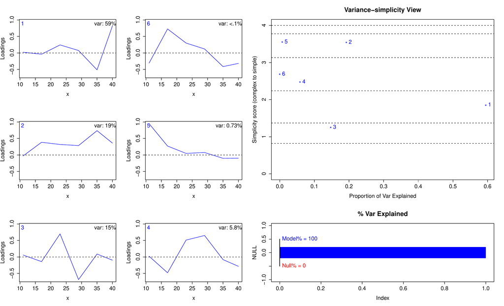

Figure 1: Analysis of the genetic covariance matrix of the caterpillar data using a model space of dimension 6 and first divided difference simplicity measure. Shown is the default output of the plot method: the six principal components of the covariance matrix and the variance-simplicity view and percent of variance explained panel.

#### The `summary` method and `display=list()` argument for the caterpillar data

Now consider the case with model space of dimension $J=5$ and `simpledim = 1`, the dimension of the nearly null space. In this case, the nearly null space is the same space as that spanned by the sixth principal component. Thus the `simpart` output and plot will be identical to Figure 1, save for colour labelling.

```r
> cat.sim.5 <- simpart(caterpillar, simpledim = 1, x = x.cat, cov = TRUE)
```

The `summary` method prints the simplicity measures, the percents of variance explained and the cumulative percents of variance explained of the basis vectors of both the model space and the nearly null space. If we set `loadings=TRUE`, then the `summary` method also prints the basis vectors of both the model space and the nearly null space.

```r
> summary(cat.sim.5, loadings = TRUE)
Simple partition (first divided differences): 1 simple basis

                 model 1  model 2  model 3  model 4  model 5  simple 1
Simplicity           1.85     3.54     1.25     2.47     3.55     2.68
%-var explained      59.5     19.2     14.7     5.85    0.731      <.1
Cumulative %-var     59.5     78.7     93.4     99.3      100      <.1

Loadings:
    model 1  model 2  model 3  model 4  model 5 simple 1
11    0.022   -0.031    0.059    0.022    0.948   -0.308
17   -0.038    0.384   -0.141   -0.479    0.270    0.727
23    0.243    0.317    0.698    0.510    0.047    0.300
29    0.074    0.284   -0.687    0.650    0.074    0.121
35   -0.512    0.736    0.088   -0.082   -0.102   -0.413
40    0.819    0.359   -0.098   -0.284   -0.098   -0.317
```

In calculating the percent of total variance explained, `summary` “restarts” the accumulation for the simplicity basis. In the `summary` output, we see, for example, that the basis vector in the $1$-dimensional nearly null space has a simplicity score of $2.68$ and explains less than $1\%$ of the total variance. The cumulative percent of total variance explained is also less than $1\%$ – this provides no additional information in this case, when the nearly null space is $1$-dimensional. We know, due to the required reconstruction of the matrix `caterpillar`, that the percent is actually equal to $0$. We can check this with the following command.

```r
> cat.sim.5$variance
$model
[1] 0.618482630 0.199899686 0.153080939 0.060800542 0.007597639
$simple
[1] 2.305732e-17
$full
[1] 0.618482630 0.199899686 0.153080939 0.060800542 0.007597639 0.000000000
```

We see that `cat.sim.5$variance$simple` is essentially equal to $0$ and that `cat.sim.5$variance$full[6]`, the variance associated with the sixth eigenvalue from the full eigenanalysis, is equal to $0$.

We now consider a more interesting higher-dimensional nearly null space, setting `simpledim = 2`. The resulting model basis vectors are identical to the first four model basis vectors in Figures 1, as these are the first four principal components of `caterpillar`. We can make a plot similar to Figure 1, but instead we plot just the two basis vectors of the nearly null space. We do this with the `display = list()` argument in the `plot` method.

```r
> cat.sim.4 <- simpart(caterpillar, simpledim = 2, x = x.cat, cov = TRUE)
> plot(cat.sim.4, display = list(simple = c(1, 2)))
```

This is shown in Figure 2.

Recall that the default plot, without the `display = list()` argument, would contain all of the model and nearly null space basis vectors. If the data vectors or the covariance matrix have high dimension, an unappealing number of subplots would be generated. Because of this, the `plot` method plots a maximum of six basis vectors. With the caterpillar data, this is not an issue because the data are only $6$-dimensional. If the data are higher-dimensional, the user must either specify six or fewer basis vectors to plot or resort to another plotting method, such as using `basisplot`, illustrated in the next section.

#### The `print` command for the caterpillar data

The `print` command gives simplicity measure information: the measures of the basis vectors constructed according to the `simpart` call and the measures of the “full space” simplicity basis vectors - that is, the basis vectors of $\Re^d$ that would be constructed if we were to set `simpledim` equal to $d$.

```r
> print(cat.sim.4)
Call:
simpart(y = caterpillar, simpledim = 2, x = x.cat, cov = TRUE)

Simplicity measure: first divided differences

Partition simplicity (2 simple basis):
 model 1  model 2  model 3  model 4 simple 1 simple 2
1.848069 3.539756 1.245756 2.471847 3.726200 2.501706

Full space simplicity:
  full 1   full 2   full 3   full 4   full 5   full 6
4.000000 3.773655 3.132870 2.237603 1.370816 0.818390
```

Note that the maximum simplicity score is 4, as claimed. We now study the percent of variance explained in the nearly null space.

```r
> cat.sim.4$varperc$simple
[1] 0.6244724 0.1061671
> summary(cat.sim.4)
Simple partition (first divided differences): 2 simple basis

                 model 1  model 2  model 3  model 4  simple 1 simple 2
Simplicity           1.85     3.54     1.25     2.47     3.73     2.50
%-var explained      59.5     19.2     14.7     5.85    0.624    0.106
Cumulative %-var     59.5     78.7     93.4     99.3    0.624    0.731
```

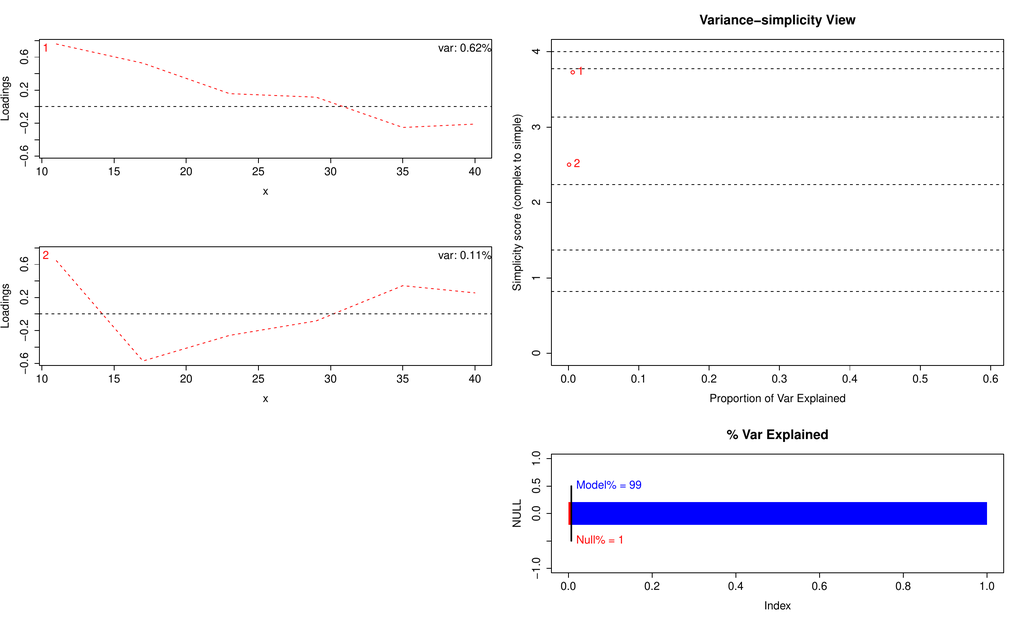

Figure 2: Analysis of the genetic covariance matrix of the caterpillar data using a model space of dimension 4 and first divided difference simplicity measure. Shown are the two basis vectors spanning the nearly null space, the variance-simplicity view and percent of variance explained panel.

#### The `reverse` argument for the caterpillar data

In principal component analysis, the signs of the loadings are arbitrary and so, in `simpart`, each basis vector can have one of two possible directions. To improve interpretability the user may want to reverse the direction of a basis vector by multiplying all of its components by $-1$. This can be done with the `rev` argument in `simpart`. The `rev` argument takes a logical vector specifying which basis vector directions we want to reverse. For example if we would like to reverse model basis vector 2 and keep the other basis vectors’ directions unchanged, we would use the following command.

```r
> plot(simpart(caterpillar, simpledim = 2, x = x.cat, cov = TRUE,
+              measure = "first",
+              rev = c(FALSE, TRUE, FALSE, FALSE, FALSE, FALSE)))
> # Reverses the second basis vector, in this case the second principal component
```

This is shown in Figure 3. The subplot in the second row of the first column contains the reversed second principal component. Compare this subplot with the one in the same position in Figure 1: it is the same except for the sign of the loadings. We would not, in general, prefer the subplot in Figure 3 because all of the loadings are negative. Indeed, if we were to see such a plot in our analysis we would use the `rev` command to reverse its direction.

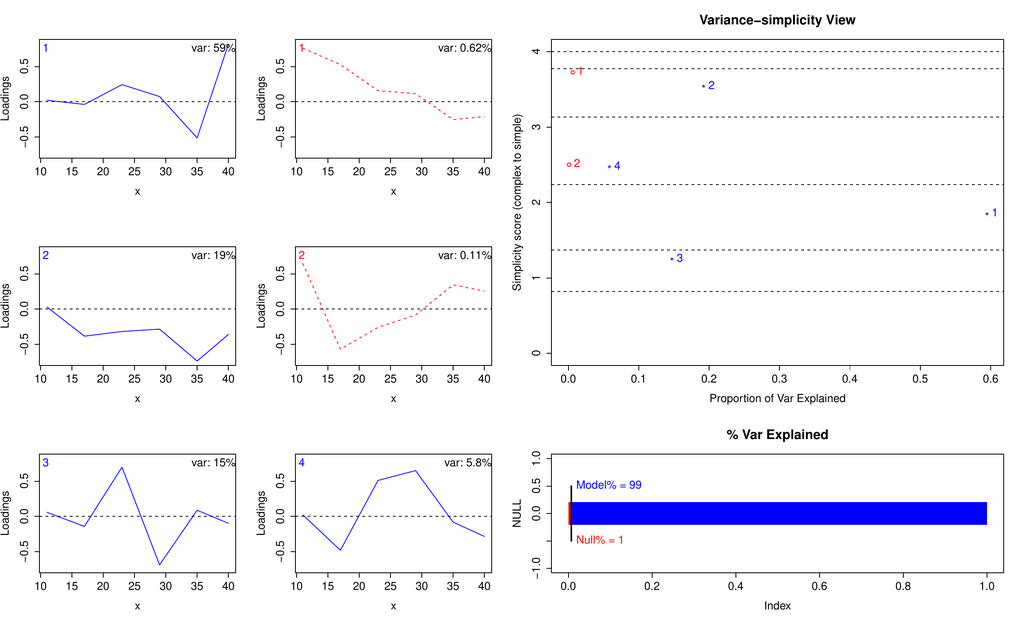

Figure 3: Analysis of the genetic covariance matrix of the caterpillar data using a model space of dimension 4 and first divided difference simplicity measure. Shown are the four basis vectors spanning the model space, the two simplicity basis vectors spanning the nearly null space, the variance-simplicity view and percent of variance explained panel. The second model basis vector is reversed.

## 5 Simulated periodic data

In this section we analyze simulated data with two simplicity measures that are useful when we expect the data to have some periodic structure “hidden” in the nearly null space. The first measure is the built-in periodic measure. While this built-in measure may be fine on its own, it produces simplicity basis vectors that are rough. We have found that the periodic simplicity measure is most useful in combination with a divided difference measure, to force smoothness of basis functions. That is the subject of our second analysis, which demonstrates how to input a function for a user-defined simplicity measure.

For both examples we use simulated data generated from sine functions. Parts of this analysis can be seen in the R demo in *prinsimp* via the command `demo(periodic)`, which will also provide the user with the function `periodic.example`. We have fine-tuned the data parameters to make our point, but have left enough flexibility in our code to allow the interested user to experiment.

The data from the $i$th sampling unit, $i=1,\ldots,n$, are constructed from the process
$$y_{i}\left(x\right) = \alpha_{0,i} + \alpha_{1,i}\sin{\left(2\pi x/L\right)} + \alpha_{2,i}\sin{\left(2\pi x/M\right)}
+ \sum_{k=3}^{N+2} \alpha_{k,i}\sin{\left(2\pi \left(k-2\right) x/K\right)}$$
where $\alpha_{k,i}$ is distributed as $N(0, a_k^2)$, $k=0,\ldots,N+2$. The data are $y_{ij} \equiv y_i(j) + \epsilon_{ij}$ with $\epsilon_{ij}$ distributed as $N(0, e^2)$ for $j=1, \dots ,J.$ All random variables are independent.

The function `periodic.example` produces one simulated data set of `n` independent vectors, each of length $J=$`x.max`.

```r
> periodic.example(L = 72, M = 5, K = 12, a0, a1, a2, sd.sigma, e, n = 100, x.max)
```

The arguments of `periodic.example` are `L`, `M` and `K`, which define the periods of the different components of the $N+2$ underlying sine functions, and the standard deviations of the random variables: `a0` $=a_0$, `a1` $=a_1$, `a2` $=a_2$, `sd.sigma` equals the vector $(a_3, \ldots, a_{N+2})^{T}$ and `e` $=e$. We simulate a $J=72$ by $n=100$ data matrix for analysis.

```r
> # Simulate using demo(periodic)
> example <- periodic.example(a0 = 4, a1 = 4, a2 = 0, sd.sigma = 0.2,
+                             e = 1, x.max = 72)
```

Thus the data from subject $i$ are obtained from the process
$$y_{i}\left(x\right) = \alpha_{0,i} + \alpha_{1,i}\sin{\left(2\pi x/72\right)} + \alpha_{3,i}\sin{\left(2\pi x/12\right)}$$
observed at $x=1,\ldots, 72$, with measurement error added, with error standard deviation $1$. The standard deviations of $\alpha_{0,i}$, $\alpha_{1,i}$ and $\alpha_{3,i}$ are, respectively, $4$, $4$ and $0.2$. Figure 4 contains a plot of the the first $15$ data sets.

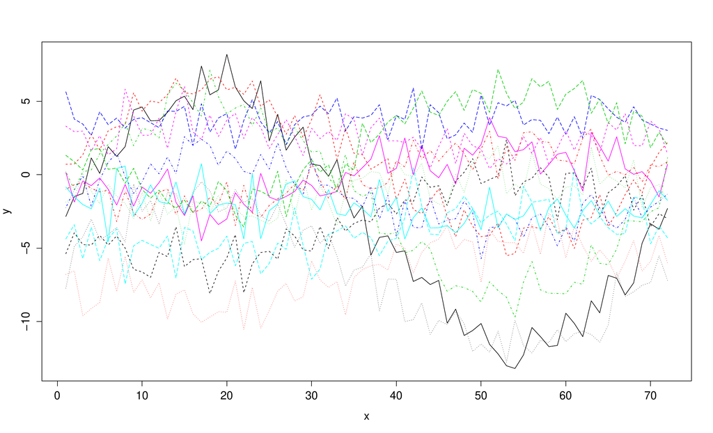

Figure 4: The plot of the data from the first 15 of the 100 curves of simulated periodic data observed at 72 values of x.

We will use `simpart` to analyze our high-dimensional data and see if we can locate any periodic structure. Recall that we simulated the data {$y_{ij}$} using sine functions $\sin{(2\pi \cdot/72)}$ and $\sin{(2\pi \cdot /12)}$, functions whose periods are, respectively, $72$ and $12$, and that the variance of the random coefficient of the period $12$ function is small. We show that PCA will not pick up the period $12$ variability in the data, nor will `simpart` with the periodic simplicity measure. However, `simpart` with a smoothed periodic simplicity measure easily identifies the period $12$ structure.

We begin with model space determination. This determination is the same as determining the number of components to retain in principal component analysis: by using either `princomp` or `simpart` with `simpledim = 0`, we can study the percent of variance explained. With this analysis, we see that a model space of dimension $J=2$ explains approximately $96\%$ of the sample variability, and the third principal component only explains an additional $0.22\%$. Figure 5 shows that the first principal component captures the constant function structure while the second principal component captures the structure with period $72$. Moreover, we see no structure in the third through the sixth principal components. Figure 5 was produced as follows, using `basisplot`.

```r
> # We do not need to specify the x vector because
> # the data are present in unit increments from 1 to 72, the default for x
> periodic.full <- simpart(example, simpledim = 0, "periodic", period = 12)
> par(mfrow = c(3, 2))
> basisplot(periodic.full, display = list(model = 1:6))
```

The chosen measure has no effect on the model basis vectors, as these vectors are simply the principal components of the covariance matrix.

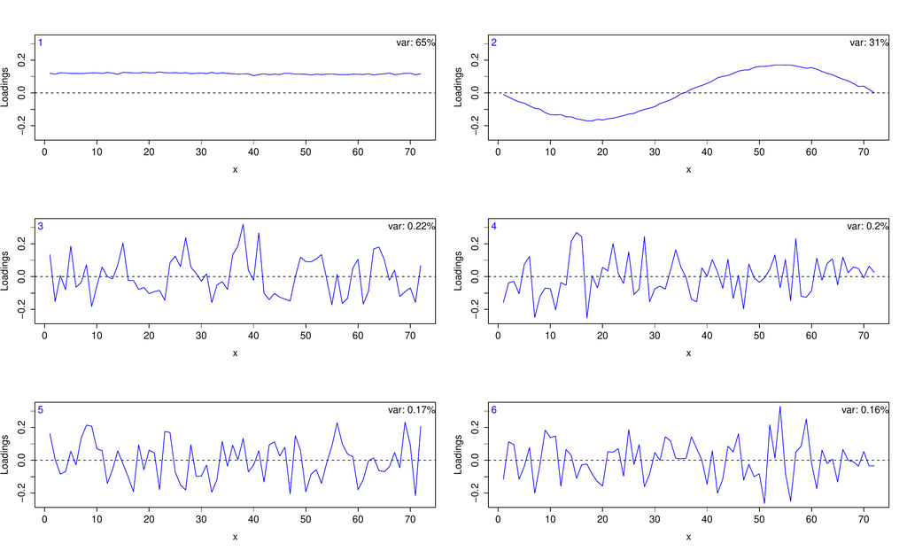

Figure 5: Analysis of the 100 curves of the simulated periodic data set (see Figure 4). Plotted are the first six principal components of the $72\times72$ sample covariance matrix, illustrating that PCA is unable to capture the period-12 component of variation.

Most researchers would see no reason to look beyond a $2$-dimensional model space. But suppose we expect to find low variability structure with period of $12$ in our data. We input our data to `simpart` specifying a periodic simplicity measure with period of $12$. Since $x=(1,2,\ldots, 72)^T$, the index period and the usual time-based period are the same.

```r
> periodic.sim <- simpart(example, simpledim = 70, measure = "periodic", period = 12)
> #  Produce Figure 6.
> par(mfrow = c(3, 4));  basisplot(periodic.sim, display = list(simple = 1:12))
```

In Figure 6, we see that the first $12$ vectors in the simplicity basis are quite rough and explain little of the variance. Our goal is to find simplicity basis vectors that are simple (periodic or close to periodic with period $12$) and explain some non-negligible proportion of the variance. The easiest way to find these simplicity basis vectors is via the plot in Figure 7, produced by the following.

```r
> plot(periodic.sim$variance$simple, periodic.sim$simplicity$simple,
+      xlab = "Variance", ylab = "Simplicity")
```

We see that there are no vectors that have both a high simplicity score and explain noticeably more variance than the others.

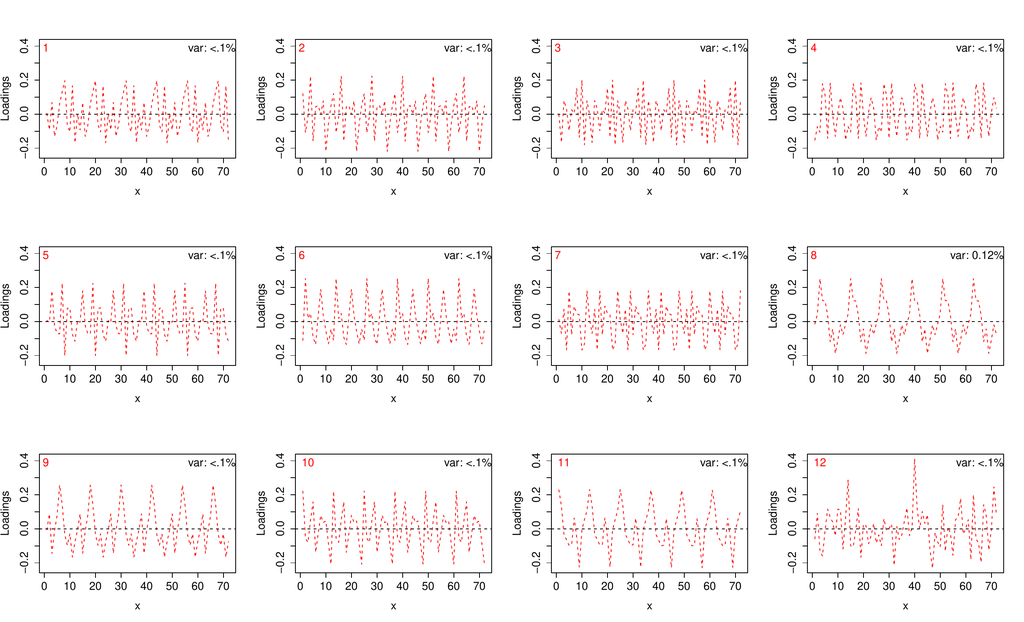

Figure 6: Prinsimp analysis of the simulated periodic data set. Plotted are the first 12 simplicity basis vectors using a model space of dimension 2 and periodic simplicity measure with period of 12. We see that this analysis is unable to capture the period-12 component of variation

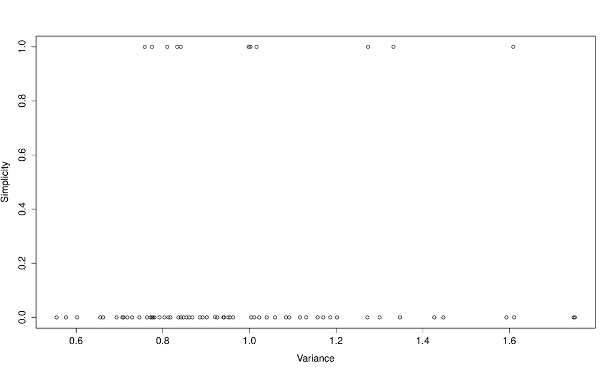

Figure 7: From the analysis as in Figure 6, a plot of the simplicity scores versus the associated variance explained for the 70 simplicity basis vectors. No simplicity basis vector stands out as “important” - as explaining a lot of the variaion and having a high simplicity score.

#### Plotting individuals’ simplicity and pc scores

Just as in principal components analysis, we can look at individuals’ scores to detect outliers or group structure. For a given basis vector $v$ and an individual with mean-centered data vector $w$, the associated score is $v'w$. When $v$ is a model space basis vector, $v'w$ is the usual principal components score. If $v$ is a nearly null space basis vector, we say that $v'w$ is the simplicity score. Figure 8 shows the plot generated by the following command. The plot isn’t very interesting, due to the regularity of our simulated data.

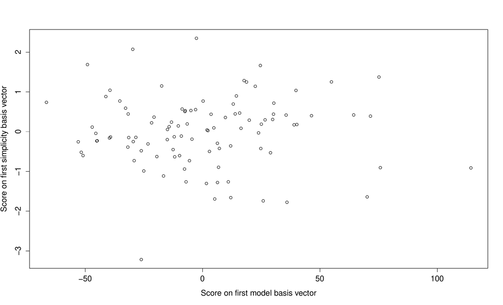

Figure 8: From the analysis as in Figures 6 and 7, a scatterplot of individuals’ first principal components scores and first simplicity basis scores.

```r
> plot(periodic.sim$scores[,1], periodic.sim$scores[,3],
+      xlab = "Score on first model basis vector",
+      ylab = "Score on first simplicity basis vector")
```

### 5.1 Periodic example with user defined simplicity measure

In addition to `simpart`’s three built-in measures, `simpart` allows the user to pass a user-defined function to `measure`. We provide details for one function, which calculates a weighted combination of the two built-in measures, the second-divided difference measure and the periodic simplicity measure.

The previous `simpart` analysis used `measure = "periodic"`. However, the periodic simplicity measure was not able to pick up any structure in the nearly null space. In addition, the simplicity basis vectors were very rough. If we expect to see low variability structure in our data that is not only periodic but also smooth, we should incorporate smoothness into our periodic simplicity measure. An easy way to do that is by using a simplicity measure that is a weighted sum of the periodic and the second divided difference measures. This will force the leading periodic simplicity basis vectors to be smoother. We show how to define such a simplicity measure by writing the function `blend_measures` and passing it to `simpart`. If $\Lambda_2$ and $\Lambda_{\pi}$ are the $d \times d$ non-negative definite matrices that define the second divided differences measure and periodic simplicity measure, respectively, then we combine them by defining our new simplicity measure based on $(1-\alpha)\Lambda_2+ \alpha \Lambda_{\pi}$ for a user-chosen $\alpha$ in $[0,1]$. The function `blend_measures` creates this matrix.

```r
> blend_measures <- function(alpha, x, period) {
     (1-alpha) * prinsimp:::lambda_second(x) +
         (alpha) * prinsimp:::lambda_periodic(x, period)
}
> # Recall that the periodic simplicity measure requires an extra period argument
```

Notice that if we set `alpha = 1` then we have the built-in periodic simplicity measure, and `alpha = 0` gives us the second divided difference measure. Note that all user defined functions must include the argument x, but can also have additional arguments that are provided in the call to simpart, in this case `alpha` and `period`.

We analyze the same simulated data set as in the previous section, still using a two-dimensional model space. As before, we analyze our data with a period of $12$ in the periodic simplicity measure and try to find important simplicity basis vectors by considering Figure 9.

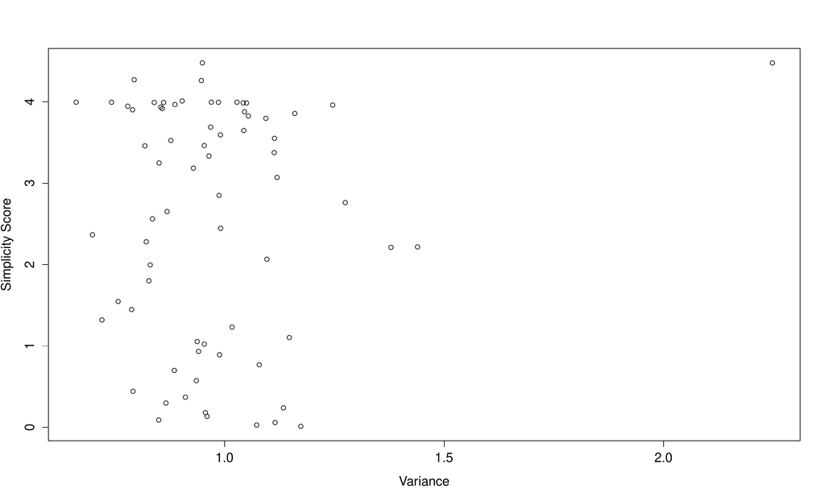

Figure 9: The simplicity score versus the variance explained of the 70 simplicity basis vectors in the analysis of the periodic data with the blended periodic-smooth simplicity measure and period 12. The outlying point in the upper right corner indicates an “important” simplicity basis vector - one that explains a lot of the variability and has a high simplicity score. This outlying point corresponds to the second simplicity basis vector, shown in the next figure.

```r
> # We will use a 50-50 weighting of the two periodic and
> # second divided difference Lambda matrices
> periodic.blend <- simpart(example, simpledim = 70,
+                           measure = "blend_measures", alpha = 0.5, period = 12)
> plot(periodic.blend$variance$simple, periodic.blend$simplicity$simple,
+      xlab = "Variance", ylab = "Simplicity Score")
```

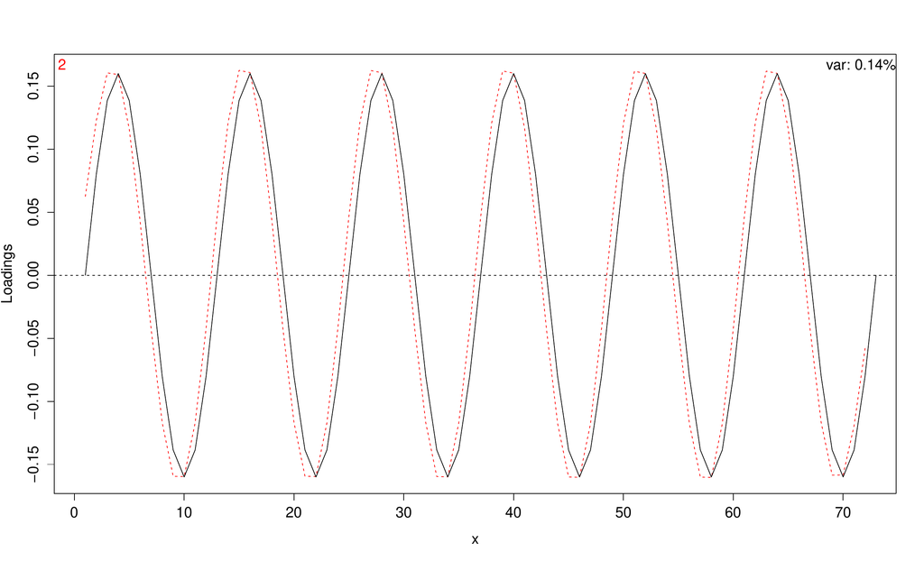

```r
> periodic.blend$variance$simple[2]
> periodic.blend$varperc$simple[2]
> basisplot(periodic.blend, display = list(simple = 2))
> lines(0.16 * sin(2*pi*(1:72)/12))
```

.

Figure 10: The second simplicity basis vector (red dashed line), which corresponds to the outlying point in the previous figure. Overlaid is a scaled sine function with period 12 (black line), indicating that the prinsimp analysis has captured the period-12 variablity.

This analysis shows how to use the function `blend_measures` to locate an important and simple direction of variability, a direction that was not captured by principal component analysis. This example also demonstrates how the periodic measure is used: the user has some idea about the structure of data and so can propose a period. The user is encouraged to experiment with the measures.

## 6 A simple user defined simplicity measure

In some applications, we may want to consider that a vector is complex if the variance of its components is large - that is, if the components are very dissimilar. This might be sensible if, for instance, the data vectors’ entries are different variables measured on similar scales, such as test scores. Thus, the complexity of the $n$-vector ${{v}}$ is $\sum_j (v[j]-\bar{v})^2$ where $\bar{v}$ is the average of the components of ${{v}}$. We can write this complexity as a quadratic form $v^T \Lambda^* v$: $\sum_j (v[j]-\bar{v})^2 = {{v}}^T {{v}}- \bar{v}^2/n = v^T ( {\rm{I}} - {\bf{1}}{ \bf{1}}^T/n) v$ where $\bf{1}$ is an $n$-vector of ones. Since the maximum eigenvalue of ${\rm{I}} - {\bf{1} }{\bf{1}}^T/n$ is $1$, our simplicity measure uses the matrix $\Lambda= {\bf{1} } {\bf{1}}^T/n$. We can use this simplicity measure in `simpart` by defining the function `constant_simple`. Since our simplicity measure only depends on the length of the input vector, we simply input any ${{x}}$ that is the same length as a data vector ${{v}}$.

```r
> constant_simple <- function(x) {
     n <- length(x)
     matrix(1,n,n)/n
  }
```

We use this function in `simpart` via `measure=constant_simple` as follows.

```r
> constant.example <- simpart(caterpillar, simpledim = 4,
+                             measure = "constant_simple", x = x.cat)
```

## 7 Implementation details

The core functionality of the *prinsimp* package is accessed through the `simpart` function. This function, as illustrated in examples above, takes in the data `y` in the form of a matrix or a formula object, the independent variable `x`, the dimension of the nearly null space (argument `simpledim`), and the simplicity measure (argument `measure`). Optionally, `y` can contain the covariance matrix itself, which is signalled with argument `cov=TRUE`.

The value returned by `simpart` is an S3 object of class `"simpart"`, with the following named components:

- `model`, `simple`: basis of the model and nearly null space, respectively, with vectors arranged in columns.
- `variance`: a list of variances associated with the vectors in the model and nearly null spaces (components `model` and `simple`), as well as the eigenvalues of the covariance matrix (component `full`).
- `varperc`: a list of the percent of variance explained by the corresponding basis vector in the model and nearly null space (components `model` and `simple`).
- `simplicity`: a list of simplicity values of vectors in the model and simplicity basis (components `model` and `simple`), and the simplicity values of the simplicity basis when `simpledim=d` (component `full`).
- `measure`, `call`: the simplicity measure used and the call object

In addition, when the `y` argument is a data rather than covariance matrix, the result includes the component `scores`, for scores on the basis vector loadings.

The *prinsimp* package provides a range of methods to view objects of class `simpart`. In addition to the `print` and `summary` methods for printing out the basis vectors, simplicity scores, and variances to the console, the user can also view them graphically. The `plot` method that we have used above puts together the collage of basis vectors along with variance-simplicity view and the percent of variance explained panel. The individual subplots can also be displayed alone, using the functions `basisplot`, `varsimp`, and `varperc`. (The `plot` method merely sets up the layout and calls those functions for the actual plotting.)

### 7.1 Writing custom simplicity functions

As mentioned earlier, as an alternative to using one of the built-in simplicity measures, the user can provide his or her own measure by passing a custom function as the value of the `measure` argument. This function returns the $\Lambda$ matrix of the measure; i.e., the simplicity score of a vector ${{v}}\in \Re^d$ is ${{v}}^T \Lambda\ {{v}}$. The custom function has to have at least one argument, named `x`, that receives values of the independent variable $x$ as given to `simpart`. The custom function is allowed to have additional arguments; these are included in the call to `simpart`, and simply passed through to the measure function.

### 7.2 CRAN packages used

prinsimp

### 7.3 CRAN Task Views implied by cited packages

D. Cubranic, J. Zhang, N. Heckman, T. Gaydos and and J. S. Marron. *Prinsimp: Finding and plotting simple basis vectors for multivariate data.* 2013. URL http://CRAN.R-project.org/package=prinsimp. R package version 0.8-8.

E. Demidenko. *Mixed models: Theory and applications.* Hoboken, NJ: Wiley-Interscience, 2004.

P. H. C. Eilers and B. D. Marx. Flexible smoothing with B-splines and penalties. *Statistical Science*, 11(2): 89–121, 1996.

T. Gaydos, N. E. Heckman, M. Kirkpatrick, J. R. Stinchcombe, J. Schmitt, J. Kingsolver and J. S. Marron. Visualizing genetic constraints. *Annals of Applied Staistics*, 7(2): 860–882, 2013.

P. J. Green and B. W. Silverman. *Nonparametric regression and generalized linear models: A roughness penalty approach.* London: Chapman & Hall, 1994.

R. A. Johnson and D. W. Wichern. *Applied multivariate statistical analysis.* Pearson, 2007.

J. G. Kingsolver, G. J. Ragland and J. G. Shlichta. Quantitative genetics of continuous reaction norms: Thermal sensitivity of caterpillar growth rates. *Evolution*, 58: 1521–1529, 2004.

M. Schatzman. *Numerical analysis: A mathematical introduction.* Oxford: Claredon Press, 2002.

F. Yao, H.-G. Mueller and J.-L. Wang. Functional data analysis for sparse longitudinal data. *Journal of the American Statistical Association*, 100: 577–590, 2005.

X. Zhao, J. S. Marron and M. T. Wells. The functional data analysis view of longitudinal data. *Statistica Sinica*, 14: 789–808, 2004.